# Using Symbolic Regression to Model Molecular Mass in Naturally Occurring Hydrocarbon Fluids

Advisor: Dr. A. Cohen

Author

Delanyce Rose & Richard Henry

Published

August 6, 2025

Slides: here

Video: [here](https://drive.google.com/file/d/1R-Rdh6zhaPpIMUNRURnB_zTObqIdnXzf/view?usp=drive_link)

## Introduction

Molecular mass is an important parameter used to model the physical properties of hydrocarbon fluids. These fluids, such as gasoline and lubricating oil are essential for so many aspects of modern life, and although these end-products are homogenized to exacting standards, the feed stock properties from which they are made vary significantly from one source to another and from the same source over time.

Unfortunately, molecular mass is expensive to measure accurately, so that it is common practice to use more easily measured parameters to estimate the value of molecular mass.

Many of these correlations (Stratiev et al. 2023) have been published over the decades, and although consensus has been reached on *which* predictor variables should be chosen, there is still considerable variation in the *form* of the equation appearing in the literature.

Rapid progress in machine learning technologies in recent years has provided a new toolbox with which we can revisit the problem. One of these tools is *symbolic regression* (Koza 1994), which had its origins in an early attempt to teach machines to code, but is now used to generate equations from data.

This technology was famously used to recreate 100 equations from the Feynman Lectures in Physics (Udrescu and Tegmark 2020), and made the jump to generating differential equations (Bongard and Lipson 2007) for describing engineering and biological systems. The story of Kepler discovering that the earth’s orbit around the sun was *not* circular based on data collected by Brahe, which upended Ptolemy’s conjecture made a thousand years previously (Brunton, Proctor, and Kutz 2016) is often repeated as an early example of symbolic regression. Like Kepler, if we are more interested in understanding the underlying relationships between variables than prediction accuracy in the presence of noise, then symbolic regression is a good place to start.

A second use case for symbolic regression concerns predicting the behaviour of systems beyond the limits of the data collected on that behaviour. Researchers at the Institute of Science and Technology (Martius and Lampert 2016) in Austria were interested in predicting the performance of a robotic arm when it is operated outside of its specifications. The hypothesis was that an equation-based *extrapolation* will fail less spectacularly than a black-box one.

## Methods

Consider a dataset consisting of an independent variable $X$ and a dependent variable $y$. Symbolic Regression (Koza 1994) allows us to discover, from the data, an analytical expression $f(X)$ which we can use to predict values of $y$ for values of $X$ unseen by the algorithm during training. For example:

$$\hat{y}_{23} \approx f(X_{23}) \tag{1}$$

Neural networks allow us to make this prediction without first generating an analytical expression. Often, this is good enough, but we give up a property called *explainability*.

In the case of a neural net, we can reclaim some of this explainability by performing a second prediction for a value of $X$ we really don’t care about, but happens to be close to $X_{23}$:

$$\hat{y}_{24} \approx f(X_{24}) \tag{2}$$

And now we can make statements on whether $y$ increases or decreases with increasing $X$ in the neighbourhood of $X_{23}$:

$$\frac{dy}{dX}|_{X_{23}}\approx \frac{\hat{y}_{24}-\hat{y}_{23}}{X_{24}-X_{23}} \tag{3}$$

The traditional alternative to neural networks which provides explainability is linear regression:

$$\hat{y}_{23} \approx \beta_0 +\beta_1 \cdot X \tag{4}$$

In which we use the data to discover the best values of the constants $\beta_0$ and $\beta_1$.

However, this may not be the best functional form for this predictive equation. For example, maybe an exponential or a logarithmic relationship may be better:

$$\hat{y}_{23} \approx \beta_2 +\beta_3 \cdot e^X \tag{5}$$

or

$$\hat{y}_{23} \approx \beta_4 +\beta_5 \cdot log(X) \tag{6}$$

or maybe

$$log(\hat{y}_{23}) \approx \beta_6 +\beta_7 \cdot log(X) \tag{7}$$

We can certainly investigate these, and hundreds of other possibilities by building multiple models and comparing the performance between them.

Alternative Conditional Expectations (Breiman and Friedman 1985) is a technology that will automatically transform both the dependent and the independent variables such that the relationship between the dependent variable and a linear combination of the independent variables is as straight as possible. Accordingly, building and testing hundreds of linear regression models can be avoided. This is different from the [Box-Cox transform](https://en.wikipedia.org/wiki/Power_transform), (See also Box and Cox (1964)) where the aim is to make the population more normal.

Although, as shown above, we can use linear regression to find non-linear relationships between variables, some relationships may be challenging, such as:

$$\hat{y}\approx\frac{\beta_0+\beta_1x+\beta_2x^2}{\beta_3+\beta_4x} \tag{8}$$

Rational fractions like this may require full-blown non-linear regression techniques which will require us to specify the form of the equation and then use the data to find the values of the constants.

A very interesting recent development (Liu et al. 2024) in this space is the Kolmogorov-Arnold Network, in which the activation functions sit on the edges instead of the nodes. Like the weights they replace in a regular conventional neural network, each one is different, and therefore by plotting the shapes of these activation functions, one could, if the network is small enough, intuit what is happening to the data as it goes through the network. Although this provides *explainability*, it does not serve up an equation.

The promise of symbolic regression is to find the optimum equation relating the independent variables to the dependent variable, which may *not* be linear, *and* the optimum values of the equation constants in the same workflow.

### Typical Workflow

1. The first step is deciding *what* we are going to encode so that the generated equations have a reasonable chance of modeling the data we present to the algorithm. Our equations will consist of operators, variables and constants, and here we are talking about operators. One may be tempted to simply include all operators known to man, but the more operators we use, the slower most algorithms run.
2. The second step is to decide *how* we are going to measure the fitness of a particular equation. The standard workflow is to decode the equation into a function, apply that function to each row in the training dataset, and then calculate the mean squared error between the target value and the equation result.
3. The third step is to decide *when* we will stop the workflow. Usually we will set a maximum number of generations *and* an error threshold that the best equation has to meet to stop the search. This equation is the one that will be offered-up as the answer at the end of the workflow.
4. The fourth step is to generate an initial population of candidate equations. The quantity is usually in the thousands, and involves the random selection of the components mentioned in the first step.
5. After the first fitness evaluation, the quality of the equations are usually quite poor. The best are selected, and then changed randomly to form the next generation, in a process influenced by biological evolution theory.
6. We then perform the fitness evaluation on the new generation. We are expecting, of course, that each generation will produce better equations than the last, *on average*.
7. Next, we check that the fitness value of the best equation and/or the number of generations tells us to stop. If not..
8. Then we again select the best and change them for the next generation.

### Toy Dataset

We are going to build a toy dataset to demonstrate the workflow. In addition to its small size (one predictor variable, 21 rows) the fact that we know *exactly* what the generating equation is gives us a yardstick to compare our results against. Here is the equation for predicting API gravity from specific gravity:

$$\gamma_{API}=\frac{141.5}{\gamma_{o}}-131.5 \tag{9}$$

Table 1: Toy Variables

| Symbol | Meaning | Units |
| --- | --- | --- |
| $\gamma_{API}$ | API Gravity | [degAPI] |
| $\gamma_o$ | specific gravity | [1/wtr] |

And here is our dataset:

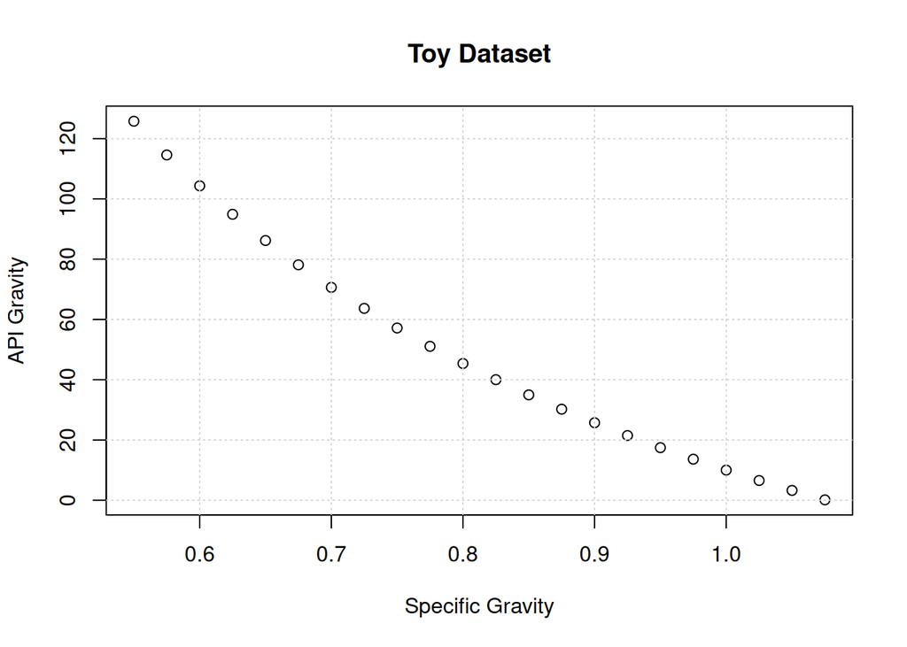

Figure 1: Pre-Fit

```r
# Generate Dataset
x<-seq(from=0.55,to=1.075,by=0.025)
y<-141.5/x-131.5
# Draw Graph
plot(x,y,main="Toy Dataset",
    xlab="Specific Gravity",
    ylab="API Gravity")
grid()
```

### Software Implementation

Most libraries available in Python for Symbolic Regression follow the `Scikit-Learn` grammar model. We will use the `PySR` library (Cranmer 2023) for demonstration purposes. First, we import the main function for the library:

`from pysr import PySRRegressor()`

Next, we call the main function to set-up the model. Here, we are using default parameters for everything:

`myMod=PySRRegressor()`

Following that, we instruct the software to search for a suitable equation for the data we have provided:

`myMod.fit(x.reshape(-1, 1),y)`

Here, `x` is specific gravity and `y` is the API gravity. The `reshape` is necessary as `Scikit-Learn` expects more than one predictor variable.

Next, we can check the quality of the fit by plotting the predicted values against the original values:

`y_pred=myMod.predict(x.reshape(-1, 1))`

The reader will notice that we have neglected to divide our dataset into `test` and `train` buckets for this demonstration.

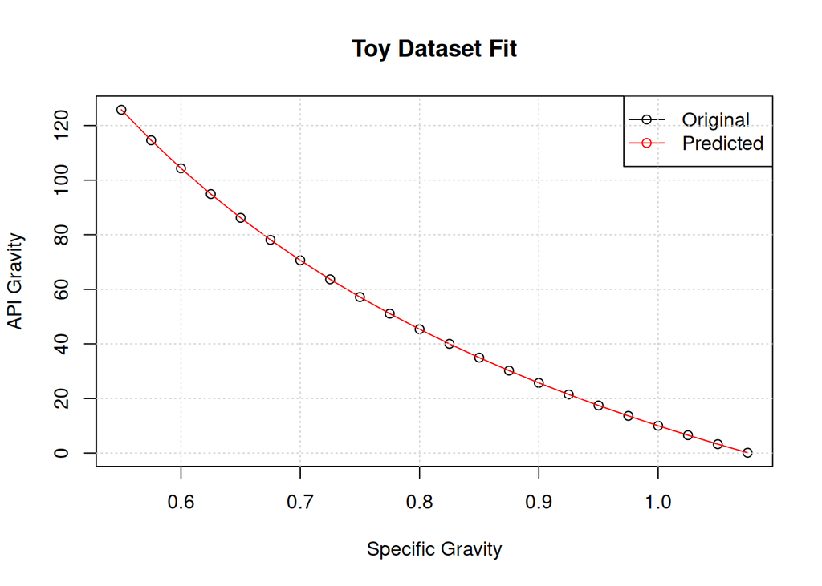

Figure 2: Clean Fit

```r
# Mimic Results from synthDataSets.ipynb
y_fit<-141.5/x-131.500000554
y_raw<-141.5/x-131.5
# Draw Raw and Fit together
plot(x,y_raw,
    main="Toy Dataset Fit",
    xlab="Specific Gravity",
    ylab="API Gravity")
lines(x,y_fit,
    type="l",
    lty=1,
    col="red")
legend("topright",
    legend=c("Original","Predicted"),
    col=c("black","red"),
    lty=c(1,1),
    pch=c(1,1))
grid()
```

Next, if we like what we see, we can ask to inspect the final equation:

`myEq=myMod.sympy()`

And the evolutionary algorithm will typically present an output that looks like this:

$$x_0-(x_0+0.013196754)+1.0131962+ \frac{x_0 (-132.5)- -141.5}{x_0} \tag{10}$$

This looks bloated, but we put it on a diet using a symbolic mathematics library (or high-school algebra):

`sym.simplify(myEq)`

which produces a much slimmer:

$$-131.500000554+\frac{141.5}{x_0} \tag{11}$$

Python is using $x_0$ to refer to the first dependent variable, which in this case is just $\gamma_o$.

### Noisy Toy

One of the challenges of *real* data is that it is noisy. Accordingly we will add some noise to our toy dataset:

`w=(random.rand(21)-0.5)*2.5`

and re-run it to see whether symbolic regression is robust enough to handle noise:

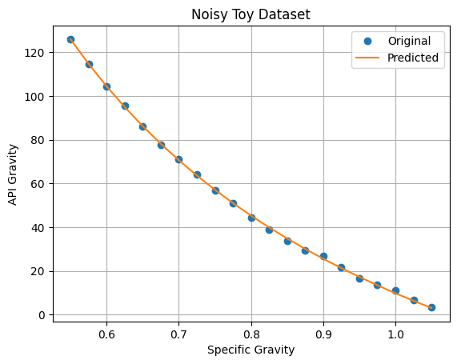

Figure 3: Noisy Fit

This uniformly distributed noise was enough to throw-off the estimation of the constants a bit, but the form of the equation was preserved:

$$-132.05688+\frac{141.88547}{x_0} \tag{12}$$

### Belly of the Beast

There are a large number of hyper parameters in a typical symbolic regression model, and we defaulted all in the Toy dataset model above.

Here are a *few* of them:

#### Step 1 (Encoding)

`binary_operators=["+","-","*","/"]`

Here we choose which binary operators may appear in our equations. These operators work on two numbers, for example $(a+b)$. On first glance, this may appear to be restrictive, but for example, the ternary operation $(a+b+c)$ can be chained as two binaries $(a+(b+c))$.

A more serious challenge is handling underflow and overflow. In particular, the classic “division-by-zero” error appear very easily when we are randomly assembling equations using operators, variables and constants. Every library will use a different coping mechanism, but common strategies include pre-assigning a value such as zero, one or positive infinity to a calculation that will generate errors.

There are additional binary operators such as the power function $(a^b)$ or the maximum and minimum functions.

`unary_operators=None`

Here we choose the unary operators that may appear in our equations. Some libraries call these “functions” instead. Examples include sine, cosine and square root, the latter capable of being represented by a power function mentioned above.

`maxsize=30`

This is the maximum length of a generated equation. Our (true) toy equation has a length of five:

Table 2: Toy Equation Length

| 1 | 2 | 3 | 4 | 5 |
| --- | --- | --- | --- | --- |
| minus | divide | 141.5 | specific gravity | 131.5 |

Notice that the generated toy equation Equation 10 is significantly longer than this, and only shrinks to 5 after post-processing. Accordingly, we want to be liberal with this number.

As a side note, this way of writing an equation is called “Polish Notation”[^1].

`maxdepth=None`

This is the maximum depth of a generated equation. Our toy equation has a depth of three:

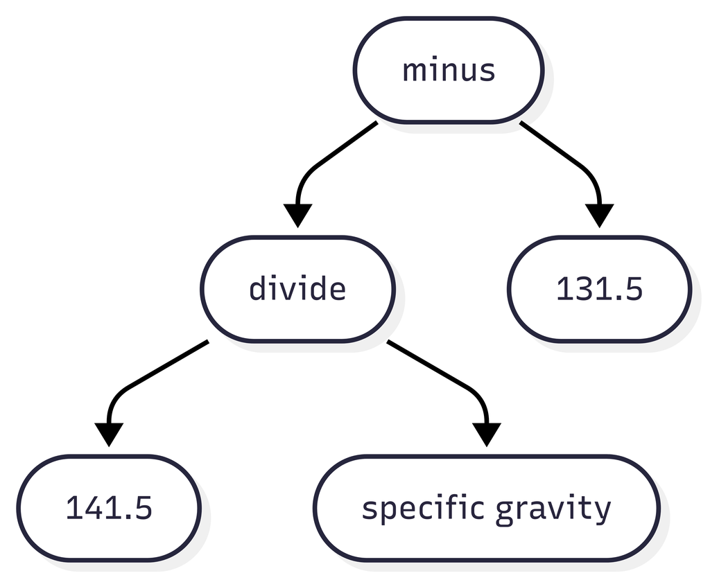

Figure 4: Toy Equation Tree

`None` in this case means that there are no restrictions on the depth of the equation.

#### Step 2 (Fitness)

`elemtwise_loss="L2DistLoss()"`

This switch says that we will use least squares to judge the accuracy of an equation. There are several canned loss functions like this, for example `L1DistLoss` will use the average absolute difference between the equation predictions and the actual values. In addition, one may define custom loss functions using Julia expressions in `PySR`.

Here is our Mean Squared Error (`L2DistLoss`):
$$\frac{1}{n} \sum_{k=1}^{n}{\left(\hat{y}_k-y_k \right)}^2 \tag{13}$$
and our Mean Absolute Error (`L1DistLoss`):
$$\frac{1}{n} \sum_{k=1}^{n}{\left|\hat{y}_k-y_k \right|} \tag{14}$$
The latter is thought to be less sensitive to outliers. For both these equations:

Table 3: Loss Function Terminology

| Symbol | Description |
| --- | --- |
| $\hat{y}_k$ | $k^{th}$ predicted value |
| $y_k$ | $k^{th}$ measured value |
| $n$ | total number of values |

`parsimony=0.0`

This is a regularization weight. Unlike Lasso or Ridge regression, the length of the equation is penalized instead of the size of the coefficients. Other libraries consider the length of the equation and over-simplified measure of complexity and propose other measures.

The idea here is that a simple equation that is very nearly as accurate as a complex one is more “explainable”, and therefore there needs to be a mechanism to encourage simpler equations.

`model_selection="best"`

This switch says that the models selected will be a specified trade-off between accuracy and complexity. There are other formulations such as `score` involving log-loss derivatives or one could simply choose `accuracy`.

`should_simplify=True`

This switch says that occasionally equations generated during the search will be simplified. Superficially, it may appear to be a good idea to simplify the equations after *every* generation, to cut down on “bloat” or equations that are more complex than they need to be. For example, $(x_0+5x_0-2x_0)$ vs. just $(4x_0)$.

However, the `PySR` developers found that allowing some bloat improved the search significantly.

`Tournament_selection_n=15`

In a nod to evolutionary biology, this says that models compete in groups of 15 for selection. The larger this number, the fewer “winners” there are after every round.

#### Step 3 (Stopping)

`niterations=100`

This is equivalent to an epoch in other machine learning algorithms. 100 is actually quite low. Other libraries require low thousands of epochs to produce the same result.

`max_evals=None`

This switch counts the number of equation evaluations performed, and stops the search after a specified number. Equation evaluations are a significant fraction of the run time, especially as the equations get longer and contain more [transcendental](https://en.wikipedia.org/wiki/Transcendental_function) functions.

`timeout_in_seconds=None`

This switch keeps track of the run time and stops the search after a specified number.

#### Step 4 (Population)

`populations=31`

This switch says that we are going to run 31 populations in parallel. This suggests that at the end of the run we should have 31 *almost* independent “best” solutions to choose from.

In practice, however, some populations “go extinct” which in our context means that they fail to produce reasonable equations. `PySR` does allow some “immigration” between populations, which produces benefits in both directions. The “better” populations have some diversity injected into them, and the “worse” populations are given new opportunities to succeed.

`population_size=27`

This switch says that each population will have 27 individuals. Notice that the tournament size is smaller than this, so that there is more than one competition between individual equations.

### Quiet Toy

The `PySR` library is relatively silent over control of constants. In its implementation, the equation forms are generated first, which for our toy example would be:

$$\frac{a_{00}}{x}+a_{01} \tag{15}$$

and randomly generated numbers used to fill the constants ($a_{00},a_{01}$). Then in a second step, the values of these constants are tuned to minimize errors. In more theoretically rigorous implementations of the evolutionary algorithm, such as `gramEvol`, (Noorian, Silva, and Leong (2016)) these constants, like the operators, have to be specified up front, and are selected based on fitness.

For our toy problem, we can supply a list of constants, of which only two are correct like this:

`w<-seq(from=121.5,to=161.5, by=10)`

and then the set-up for the problem would look like this:

```r
# Import Library
library("gramEvol")
# List of constants
w<-seq(from=121.5,to=161.5, by=10)
# Define the rules
ruleDef <- list(expr = grule(op(expr, expr), var,con),
                op = grule('+', '-', '*','/'),
                var = grule(x),
                con = gvrule(w))
# Create the Grammar
grammarDef <- CreateGrammar(ruleDef)
# Print Backus-Naur version
grammarDef
```

Table 4: Backus-Naur Description of Toy Problem

```
<expr> ::= <op>(<expr>, <expr>) | <var> | <con>
<op>   ::= "+" | "-" | "*" | "/"
<var>  ::= x
<con>  ::= 121.5 | 131.5 | 141.5 | 151.5 | 161.5
```

Then we can supply other important hyper parameters (e.g. fitness function, number of iterations, complexity limits) and `gramEvol` will find our function after about 1500 generations:

```r
# Fitness Function
SymRegFitFunc <- function(expr) {
  result <- eval(expr)
  if (any(is.nan(result)))
    return(Inf)
  return (mean(log(1 + abs(y - result))))
}
# Random Number Generator
set.seed(13)
# Call to main function
ge <- GrammaticalEvolution(grammarDef,
                           SymRegFitFunc,
                           terminationCost = 0.1,
                           iterations = 2500,
                           max.depth = 10)
ge
```

Table 5: gramEvol Results

```
Grammatical Evolution Search Results:
  No. Generations:  1531
  Best Expression:  141.5/x - 131.5
  Best Cost:        0
```

This approach is clearly useful when our constants can only assume specific values, for example the freezing point of water at atmospheric pressure ($273.15 K$) but less useful when we don’t know enough to define all our relevant constants ahead of time.

Virgolin and Bosman (2022) present two algorithms that adjust the value of the constants as an integral part of the evolutionary process, but conclude that “coefficient mutation does not always make a difference”. This is disappointing.

### Alternatives to Evolution

Although genetic programming has proven to be most popular approach to Symbolic Regression (Dong and Zhong 2025), it has been criticized for being slow and producing bloated equations.

Deterministic methods such as brute-force search (Udrescu and Tegmark 2020), mathematical programming (Austel et al. 2017) and sparse regression (Muthyala et al. 2025) have been employed.

Methods which rely on [information theory](https://en.wikipedia.org/wiki/Information_theory) have also been used, especially of late. (See also Shannon (2001)) The idea here is to replace the random changes to the equations that are the heart of the evolutionary approach with changes based on what we know about the data. Sometimes this information is learned from the data (Anthes, Sobania, and Rothlauf 2025), and other times it is supplied externally (Keren, Liberzon, and Lazebnik 2023) as “human experience”. In the latter case, there is the risk that the search space may become so restricted that nothing new can be learned.

Neural Network methods have also made an appearance. An early approach (Martius and Lampert 2016) replaced the activation functions in an ANN with trancendental functions such as sine and log. The main idea here is that each layer would host multiple kinds of functions instead of just one. The more recent approaches (Kamienny et al. 2022) pre-train a transformer model to learn the relationships between data and equations using synthetic data. The major advantage here is that if we ignore the pre-training phase, the training phase may be quick enough to use the model in real time.

### Sparse Toy

When sparse regression is used in symbolic regression, a large number of potential terms are generated using combinations of the independent variables. Technically, the resulting equation is only *sparse* if the number of terms exceeds the number of rows in the dataset, but usually this is not a problem. Then regularization is applied to force *most* of the generated terms to zero, dramatically shortening the length of the equation.

As later in this paper we will be comparing an algorithm based on sparse regression against one based on evolution, we provide this quick recount of an informal experiment we made on our toy dataset.

We tried to fit the following equation to the toy dataset using vanilla linear regression:

$$\hat{y} \approx \beta_{00}+\beta_{01}x_0+\beta_{02}x_0^2+\beta_{03}x_0^3 \tag{16}$$

and got a very good fit. We then added an inverse term:

$$\hat{y} \approx \beta_{00}+\beta_{01}x_0+\beta_{02}x_0^2+\beta_{03}x_0^3+\frac{\beta_{04}}{x_0} \tag{17}$$

and without even using regularization, all the terms except $\beta_{00},\beta_{04}$ were reduced to zero and we obtained a perfect fit.

This encouraged us to add exponential and logarithmic terms:

$$\hat{y} \approx \beta_{00}+\beta_{01}x_0+\beta_{02}x_0^2+\beta_{03}x_0^3+\frac{\beta_{04}}{x_0}+\beta_{05}log(x_0)+\beta_{06}e^{x_0} \tag{18}$$

and again we were thrilled to see all terms except $\beta_{00},\beta_{04}$ were reduced to (near) zero .

However, when we removed the inverse term:

$$\hat{y} \approx \beta_{00}+\beta_{01}x_0+\beta_{02}x_0^2+\beta_{03}x_0^3+\beta_{05}log(x_0)+\beta_{06}e^{x_0} \tag{19}$$

All the remaining terms got very large, even though the fit continued to be excellent.

This suggested to us that the regularization *was* an important part of sparse regression when it is used for symbolic regression.

### AI Statement

No generative AI products were used in the writing of this paper[^2]. Accordingly, the reader will encounter a shameless mixture of American and British spelling and idioms.

However, AI *was* used to coerce recalcitrant libraries to stop throwing error codes and actually produce something useful. Fortunately for the reader, this was only partially successful, or this paper would be a lot longer.

### Next Steps

1. Examine our dataset and describe some of the equations that have been used historically to calculate molecular mass.
2. Compare the equations that are generated by `PySR` for our dataset as the options are varied.
3. Compare the equations that are generated by evolutionary algorithms vs. deterministic algorithms.

## Analysis and Results

### Data Exploration and Visualization

Let us take a first look at the dataset from Goossens (Goossens 1996):

```r
# Read Goosens Dataset from flat file
# Positron
#df<-read.csv("./c694/goossens_raw.csv")
# Quarto
df<-read.csv("./goossens_raw.csv")
```

We have 3 variables:

Table 6: Goossens Variables

| Variable | Description | Designation |
| --- | --- | --- |
| $Mw$ | Molecular Mass | dependent |
| $SG$ | Specific Gravity | independent |
| $TBP$ | True Boiling Point | independent |

and 70 rows.

*Molecular Mass* is a proxy for the size of the molecule. For those of you who remember your high school chemistry, it is the mass of the substance per unit mole. *Specific Gravity* is the density of the substance divided by the density of water. Again, for those of you who remember your high school physics, density is mass per unit volume, so we are expecting these two to be related somehow. *True Boiling Point* is the temperature at which the substance boils at atmospheric pressure. The true boiling point of water is 100 C.

This is a very small dataset by modern machine learning standards. However, due to the cost of acquiring the molecular mass data, this dataset will be considered “large” by chemical engineering standards.

One of the questions we want to answer is whether datasets like this are “too small” for symbolic regression.

#### Univariate Analysis

Here is a summary of the dataset:

```r
# Summarize Goossens Dataset
print(summary(df))
```

Table 7: Goosens Dataset Summary

```
       SG              TBP               MW
 Min.   :0.6310   Min.   : 306.0   Min.   :  70.0
 1st Qu.:0.7439   1st Qu.: 373.2   1st Qu.:  99.0
 Median :0.8474   Median : 584.0   Median : 222.5
 Mean   :0.8470   Mean   : 575.2   Mean   : 304.6
 3rd Qu.:0.8784   3rd Qu.: 668.5   3rd Qu.: 297.8
 Max.   :1.3793   Max.   :1012.0   Max.   :1685.0
```

The reader will notice that the specific gravity value range is small compared to the boiling point and molecular mass ranges. Also, the mean of the molecular mass data is nowhere near its median. Lets take a closer look:

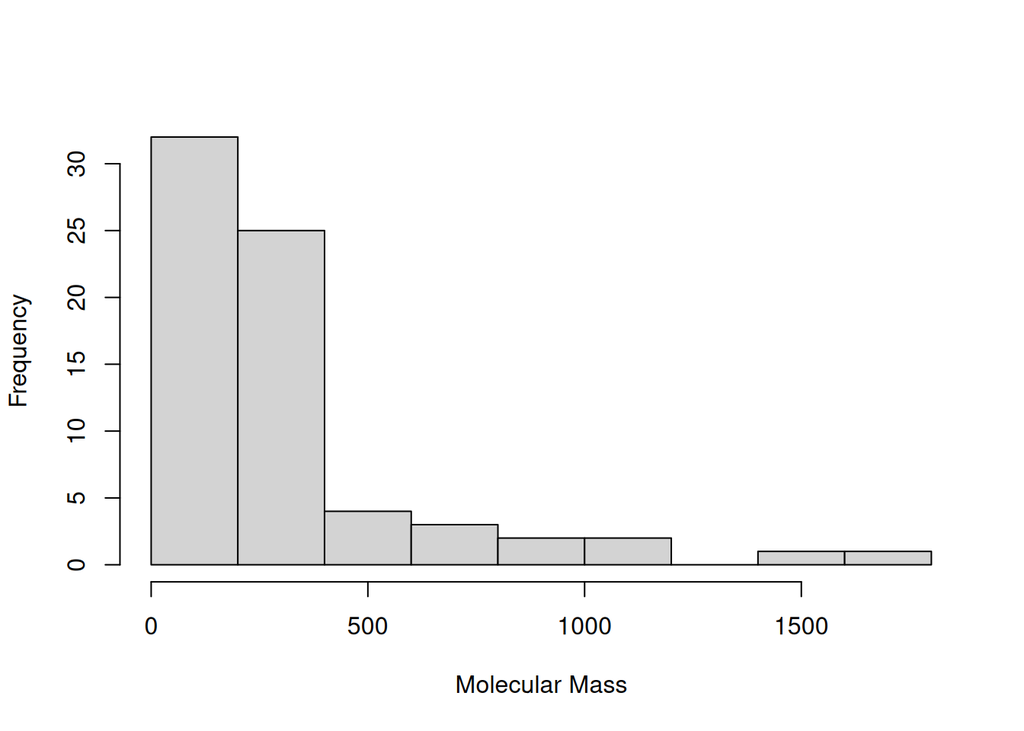

Figure 5: Raw Molecular Mass Histogram

```r
hist(df$MW,
     main="",
     xlab="Molecular Mass")
```

The reader will notice a strongly right-skewed distribution with an empty “bucket” near the top. Lets take a peek at the box plots:

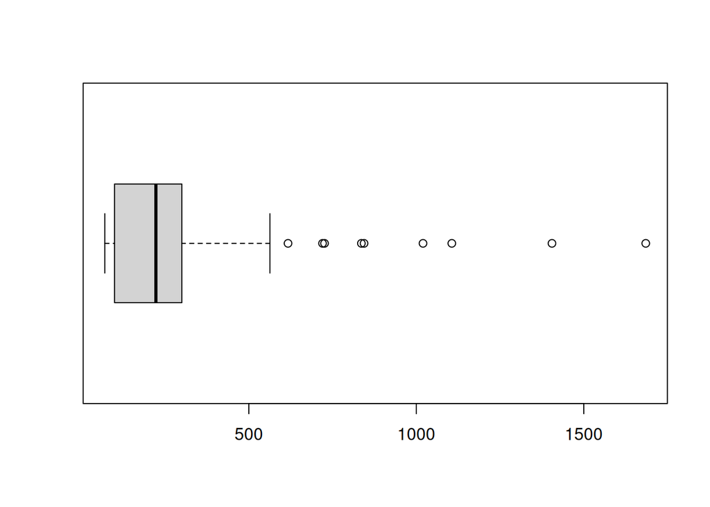

Figure 6: Raw Molecular Mass Box-and-Whiskers Plot

```r
boxplot(df$MW,
        horizontal=TRUE)
```

The reader will notice that all the values greater than about 600 would be considered outliers if the molecular masses were normally distributed.

Turning to the True Boiling Point variable:

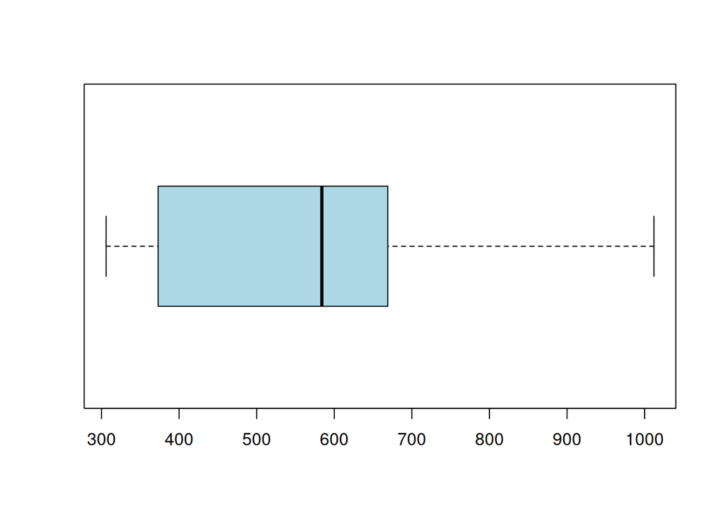

Figure 7: Raw Boiling Point Box-and-Whiskers Plot

```r
boxplot(df$TBP,
        horizontal=TRUE,
        col="lightblue")
```

We appear to have no outliers for this variable, but this variable is not normally distributed either. Lets check:

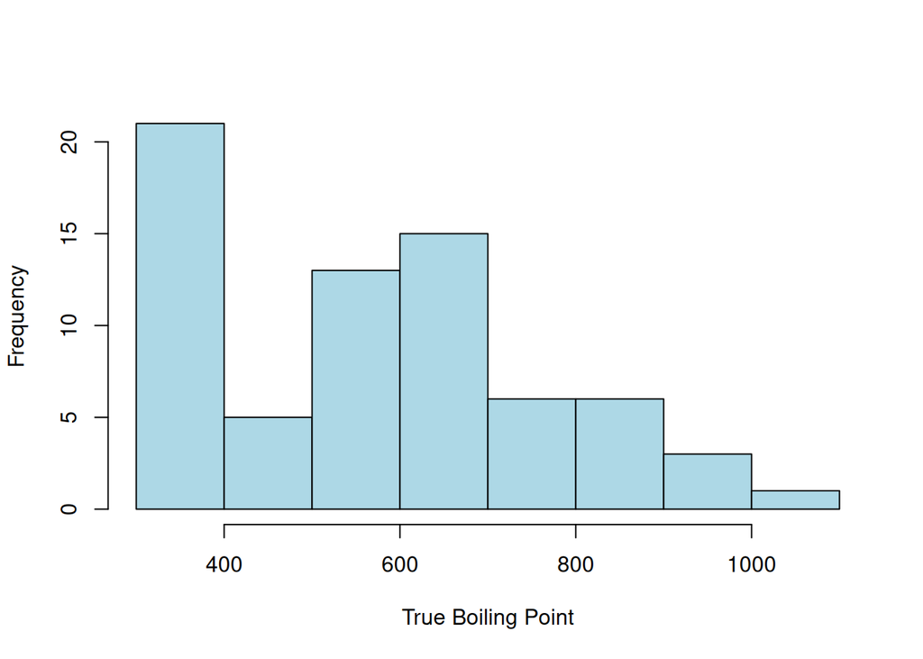

Figure 8: Raw Boiling Point Histogram

```r
hist(df$TBP,
     main="",
     xlab="True Boiling Point",
     col="lightblue")
```

We appear to have a bimodal distribution here. Lets compare this with the other predictor, specific gravity:

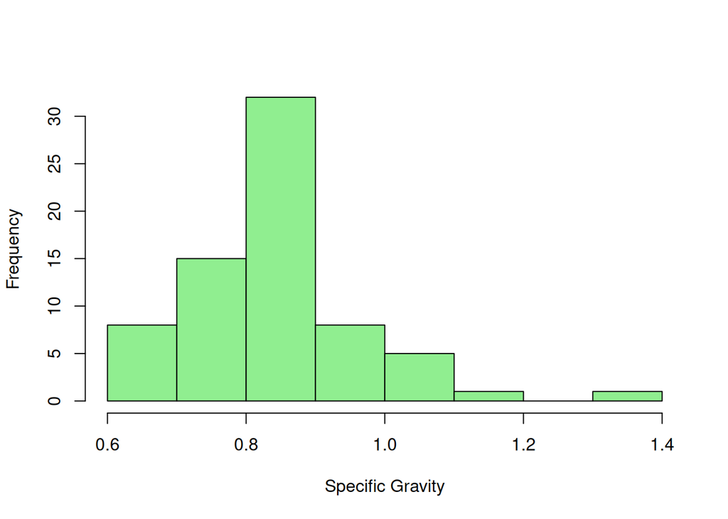

Figure 9: Raw Specific Gravity Histogram

```r
hist(df$SG,
     main="",
     xlab="Specific Gravity",
     col="lightgreen")
```

This distribution is skewed to the right, but not as strongly as molecular mass. No signs of a bimodal distribution here. Here is the box plot:

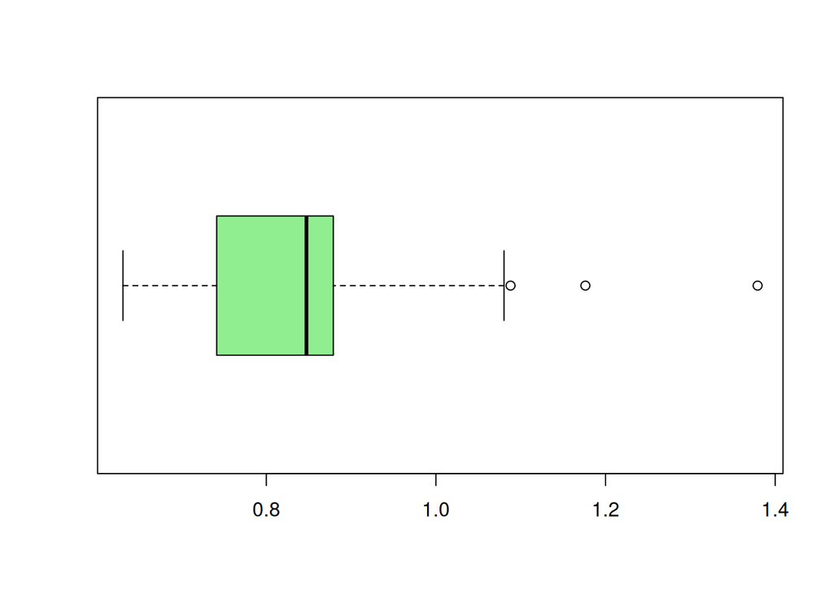

Figure 10: Raw Specific Gravity Box-and-Whiskers Plot

```r
boxplot(df$SG,
        horizontal=TRUE,
        col="lightgreen")
```

It is interesting that the largest specific gravity values appear to be outliers, even though this variable appears to be the “most normally distributed” of the three.

#### Bivariate Analysis

Here is a plot of molecular mass vs. specific gravity:

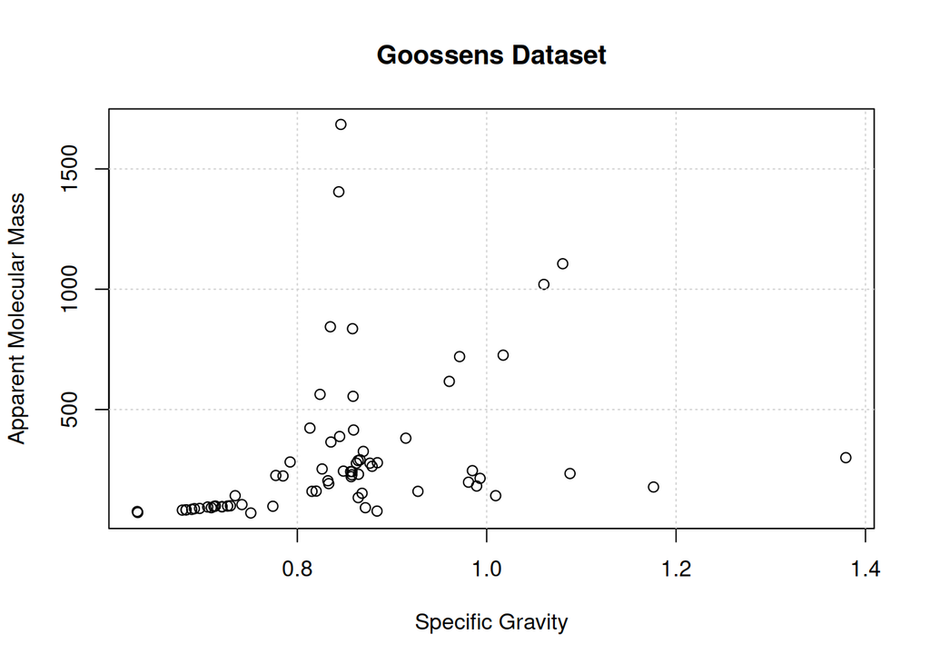

Figure 11: Molecular Mass vs Specific Gravity Goossens Data

```r
plot(df$SG,df$MW,
    main="Goossens Dataset",
    xlab="Specific Gravity",
    ylab="Apparent Molecular Mass")
grid()
```

Although there appears to be a clear linear relationship between molecular mass and specific gravity at low gravity numbers, the heteroscedasticity explodes above a gravity of about 0.75.

Notice that the molecular mass “outliers” appear to be different from the specific gravity “outliers”. A reasonable assumption going in was for these two variables to be (more) positively correlated, placing both “outlier” groups in the upper right corner of the plot.

Notice that the largest variation in molecular mass corresponds to the specific gravity range 0.8-0.9, which, according to Figure 9 is our mode.

Here is the molecular mass vs. true boiling point scatter plot:

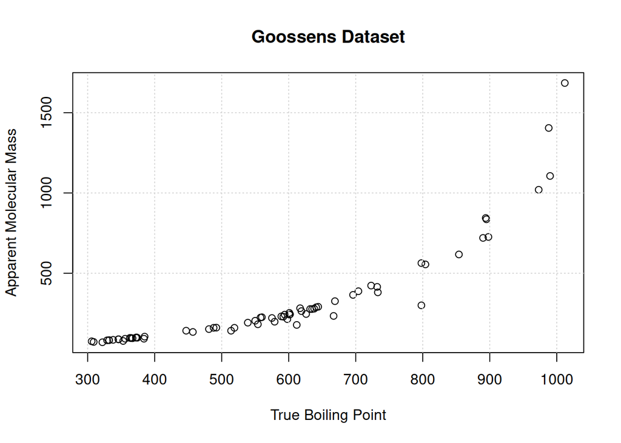

Figure 12: Molecular Mass vs Boiling Point Goossens Data

```r
plot(df$TBP,df$MW,
    main="Goossens Dataset",
    xlab="True Boiling Point",
    ylab="Apparent Molecular Mass")
grid()
```

There seems to be a monotonically increasing relationship between molecular mass and true boiling point, which matches the expectation going in, unlike Figure 11. There is a possible “pole” around the boiling point of 1000, which we will discuss in our results.

At this point, it may be tempting to ignore the effect of specific gravity on the prediction of molecular mass.

Here we plot the two independent variables against one another:

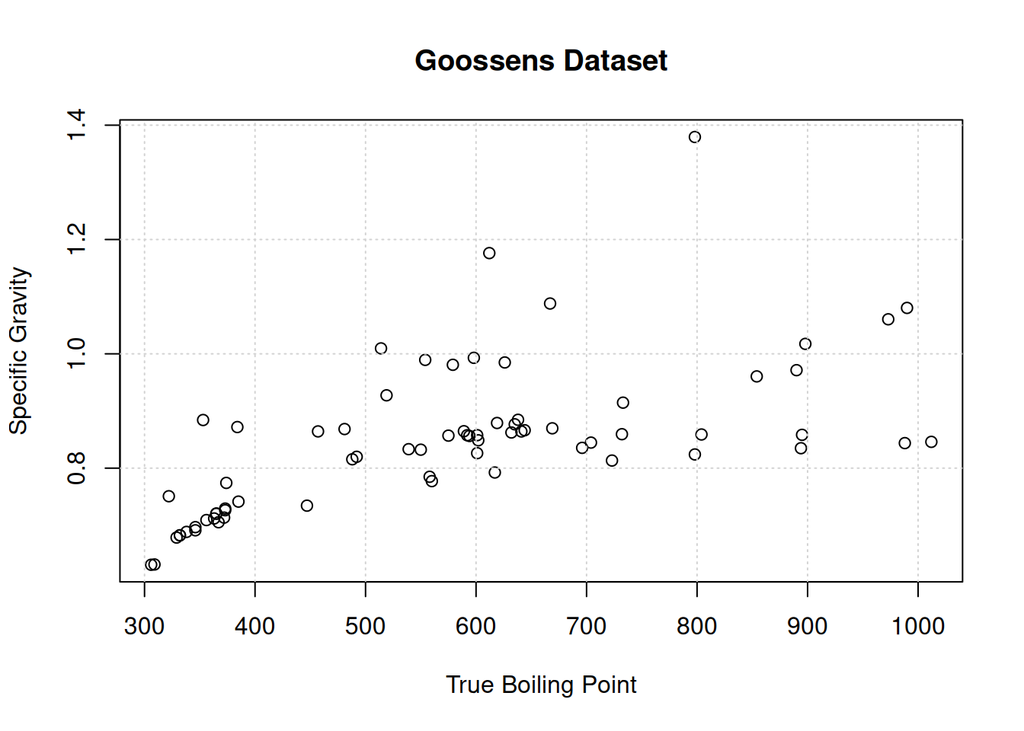

Figure 13: Specific Gravity vs Boiling Point Goossens Data

```r
plot(df$TBP,df$SG,
    main="Goossens Dataset",
    xlab="True Boiling Point",
    ylab="Specific Gravity")
grid()
```

This plot suggests that the correlation is poor between true boiling point and specific gravity. Presumably, the specific gravity helps to reduce the scatter around the trend of molecular weight vs. true boiling point.

There is a second, smaller independent dataset available publicly (Hosseinifar and Shahverdi 2021) which we can use for verification. Let us compare it to the Goossens dataset:

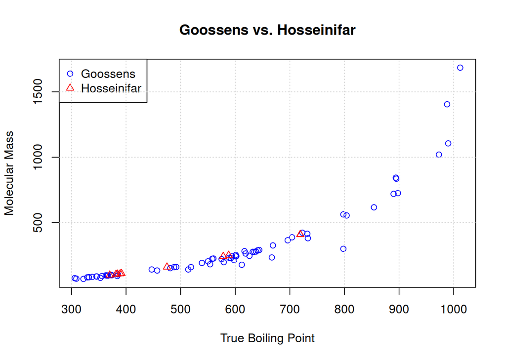

Figure 14: Molecular Mass vs Boiling Point. Both Datasets

```r
# Read Hosseinifar Dataset from flat file
# Positron
#dfh<-read.csv("./c694/hosseinifar_raw.csv")
# Quarto
dfh<-read.csv("./hosseinifar_raw.csv")
# Plot Goossens and Hosseinifar together
plot(df$TBP,df$MW,
     main="Goossens vs. Hosseinifar",
     xlab="True Boiling Point",
     ylab="Molecular Mass",
     col="blue")
points(dfh$TBP,dfh$MW,
       col="red",
       pch=2)
legend("topleft",
       legend=c("Goossens","Hosseinifar"),
       col=c("blue","red"),
       pch=c(1,2))
grid()
```

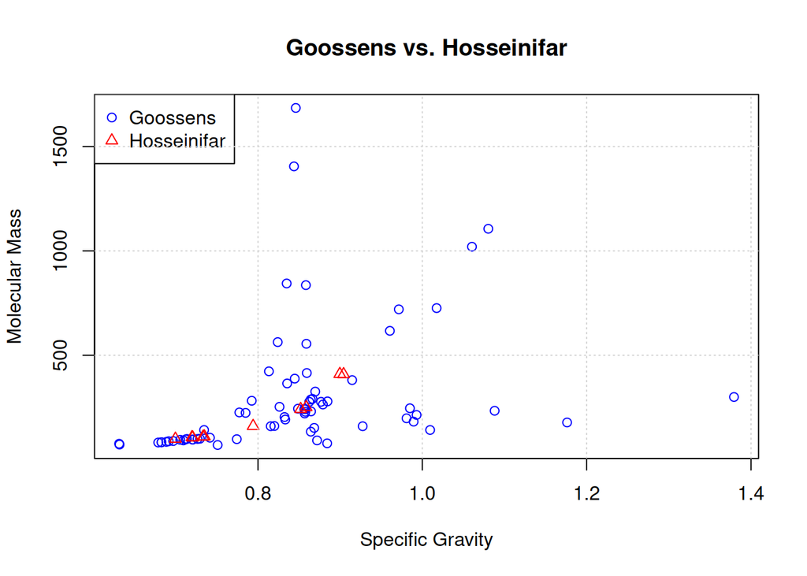

Figure 15: Molecular Mass vs Specific Gravity. Both Datasets

```r
# Plot Goossens and Hosseinifar together
plot(df$SG,df$MW,
     main="Goossens vs. Hosseinifar",
     xlab="Specific Gravity",
     ylab="Molecular Mass",
     col="blue")
points(dfh$SG,dfh$MW,
       col="red",
       pch=2)
legend("topleft",
       legend=c("Goossens","Hosseinifar"),
       col=c("blue","red"),
       pch=c(1,2))
grid()
```

The two datasets appear to be compatible, even though the variation of the Hosseinifar dataset is significantly smaller.

#### Existing Correlations

The existing correlations available for estimating molecular mass from true boiling point and specific gravity provide hints as to what kind of equations we expect to see from the algorithm. Many of them predate symbolic regression and therefore were developed by people using intuition and experimentation.

Here are a few of them using the following nomenclature:

Table 8: Correlation Nomenclature

| Symbol | Meaning |
| --- | --- |
| $M_w$ | Apparent Molecular Mass |
| $T_b$ | True Boiling Point Temperature |
| $\gamma_o$ | Specific Gravity |
| $a_{00}..a_{09}$ | Empirical Constants |
| $K_w$ | Characterization Factor (intermediate value) |
| $X_0...X_3$ | Intermediate Variables |

##### Hariu & Sage (1969)

$$M_w = a_{00} + a_{01} K_w + a_{02} K_w^2 + a_{03} T_b K_w + a_04 T_b K_w^2 + a_{05} T_b^2 K_w + a_{06} T_b^2 K_w^2
\tag{20}$$

$$K_w =\frac{\sqrt[3]T_b}{\gamma_o} \tag{21}$$

##### Kesler & Lee (1976)

$$M_w = X_0 + \frac{X_1}{T_b} + \frac{X_2}{T_b^2} \tag{22}$$

$$X_0 = a_{00} + a_{01} γ_o+ \left (a_{02} + a_{03} γ_o \right ) T_b \tag{23}$$

$$X_1 = \left (1+ a_{04} γ_o + a_{05}γ_o^2 \right ) \left (a_{06} + \frac{a_ {07}}{T_b} \right ) \cdot 10^7
\tag{24}$$

$$X_2 = \left (1+ a_{08} γ_o+ a_{09} γ_o^2 \right ) \left (a_{10} + \frac{a_{11}}{T_b} \right ) \cdot 10^{12}
\tag{25}$$

##### American Petroleum Institute (1977)

$$M_w = a_{00} e^ {\left (a_{01} T_b \right )} e^{\left (a_{02} γ_o \right )} T_b^{a_{03}} γ_o^ {a_{04}}
\tag{26}$$

##### Winn, Sim & Daubert (1980)

$$M_w = a_{00} T_b^{a_ {01}} γ_o^{a_{02}} \tag{27}$$

##### Riazi & Daubert (1980)

$$M_w = a_{00} T_b^{a_ {01}}γ_o^{a_{02}} \tag{28}$$

##### Rao & Bardon (1985)

$$ln {M_w} = (a_{00} + a_{01} K_w) ln (\frac{T_b} {a_{02} + a_{03} K_w} ) \tag{29}$$

See Equation 21

##### Riazi & Daubert (1987)

$$M_w = a_{00} T_b^{a_{01}} γ_o^{a_{02}} e^{\left (a_{03} T_b + a_{04} γ_o + a_{05} T_b γ \right )}
\tag{30}$$

##### Goossens (1996)

$$M_w = a_{00} T_b^{X_0} \tag{31}$$

$$X_0 =\frac {a_{03} + a_{04} ln {\left (\frac{T_b} {a_{05} - T_b} \right )}} {a_{01} γ_o + a_{02}}
\tag{32}$$

##### Linan (2011)

$$M_w = a_{00} e^{\left (a_{01} T_b \right )} e^{\left (a_{02} γ_o \right )} T_b^ {a_{03}} γ_o^{a_{04}}
\tag{33}$$

##### Hosseinifar & Shahverdi (2021)

$$M_w = {\left [a_{00} T_b^{a_{01}} {\left (\frac{3+2γ_o} {3-γ_o} \right )}^{\frac{a_{02}}{2}} + a_{03} T_b^{a_{04}} {\left (\frac{3+2γ_o}{3-γ_o} \right )}^{\frac{a_{05}}{2}} \right ]}^{a_{06}} \tag{34}$$

##### Stratiev (2023)

$$M_w = a_{00} + a_{01} e^{\left [a_{02} e^{\left (a_{03} \frac{T_b^{a_{06}}}{γ_o^{a_{05}}} \right )} \right ]}
\tag{35}$$

The reader will notice that all the correlations are non-linear, and that only a few of them can be easily transformed into a linear relationship. Some of the additional operators we may want to consider from an inspection of these equations include:

Table 9: Partial List of Additional Operators

| Operator | Type | Description |
| --- | --- | --- |
| pow | binary | one expression raised to the power of another |
| log | unary | logarithm of an expression |
| exp | unary | [antilogarithm](https://mathworld.wolfram.com/Antilogarithm.html) of an expression |
| sqr | unary | expression squared |
| cub | unary | expression cubed |
| inv | unary | inverse of an expression |

### Modeling and Results

In this sub-section, we will apply a series of symbolic regression models to our Goossens dataset, and look at the structure and performance of each generated equation.

#### Default Run

Our first experiment is to run `PySR` with default parameters against our molecular mass dataset. The resulting equation looks nothing like the existing equations:

$$M_w=a_{00}+\frac{a_{01}}{\gamma_o-a_{02}}+\frac{T_b\cdot (a_{03}\cdot T_b-a_{04})}{\gamma_o\cdot (a_{05}-\frac{a_{06}}{T_b})}
\tag{36}$$

But its performance is quite impressive considering its restricted grammar of addition, subtraction, multiplication and division:

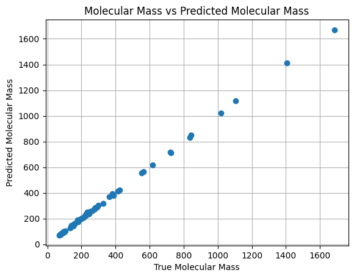

Figure 16: Default Parameter Run

It even has a (slightly) better correlation coefficient with the raw molecular mass data than Equation 31 presented with this data in the Goossens paper:

Table 10: Default Run Correlation Coefficients

|  | Raw SG | Raw TBP | Raw MW | Goossens Equation | This Equation |
| --- | --- | --- | --- | --- | --- |
| Raw SG | 1.000000 | 0.625218 | 0.334852 | 0.339126 | 0.337190 |
| Raw TBP | 0.625218 | 1.000000 | 0.869591 | 0.868486 | 0.871037 |
| Raw MW | 0.334852 | 0.869591 | 1.000000 | 0.999711 | 0.999847 |
| Goossens Equation | 0.339126 | 0.868486 | 0.999711 | 1.000000 | 0.999798 |
| This Equation | 0.337190 | 0.871037 | 0.999847 | 0.999798 | 1.000000 |

There are some challenges. The constant $a_{02}$ is only slightly larger than the largest $\gamma_o$ (specific gravity) in the dataset. This limits the extrapolation power of this equation to higher specific gravities than seen in this dataset. Extrapolation is one of the strengths of Symbolic Regression (Sahoo, Lampert, and Martius 2018)

Next, we look at the residuals, plotted against the raw molecular mass:

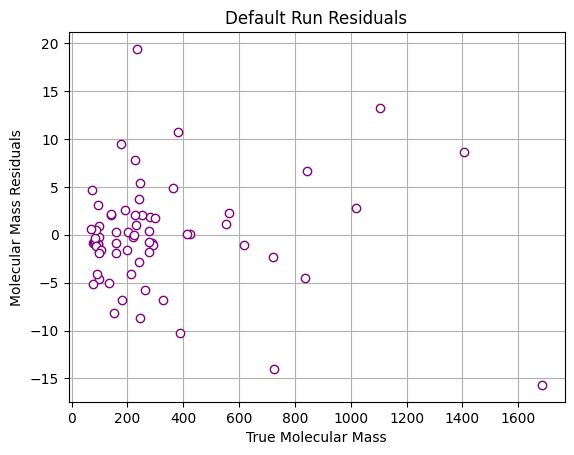

Figure 17: Default Run Residuals

Visually, the residuals *appear* to be normally distributed, but running the Shapiro-Wilk test (Shapiro and Wilk (1965)) reveals a probability of only 0.001 of the residuals being normally distributed. So much for eye-balling!

Let us see how *bad* it is:

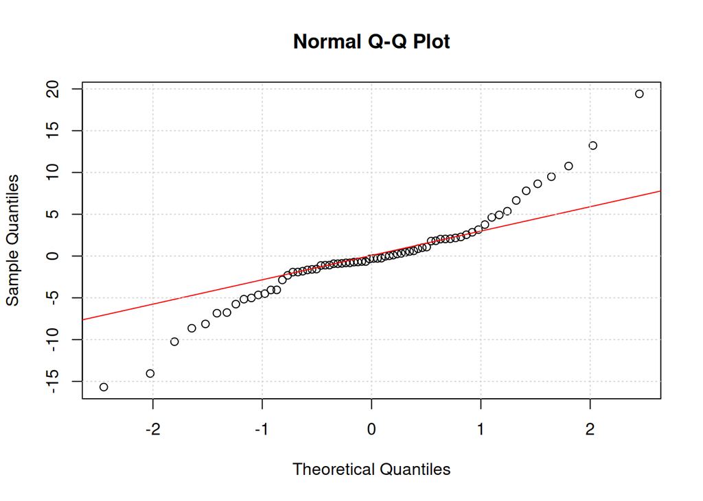

Figure 18: Q-Q Plot for the Default Run Residuals

```r
# Read Goossens Default Run results from flat file
# Positron
#df<-read.csv("./c694/default_output.csv")
# Quarto
dfd<-read.csv("./default_output.csv")
# Generate QQPlot
qqnorm(dfd$Fit_Resid)
qqline(dfd$Fit_Resid, col="red")
grid()
```

The plot suggests that small residuals (say $\pm 2.5$) are normally distributed, but the large residuals are not.

Maybe it is appropriate at this juncture to include this:

**Formal Statistical Test**

$H_0$: The residuals created by using Equation 36 to predict the molecular masses in the Goossens dataset are normally distributed.

$H_1$: The residuals are not normally distributed.

**Level of Significance**: 0.05

**Shapiro-Wilk Statistic**: 0.932714

**Shapiro-Wilk p-Value**: 0.001

**Conclusion**: We will reject the null hypothesis as the calculated p-value is less than the level of significance.

Out of mere curiosity, let us examine the residuals from the Goossens correlation (Equation 31):

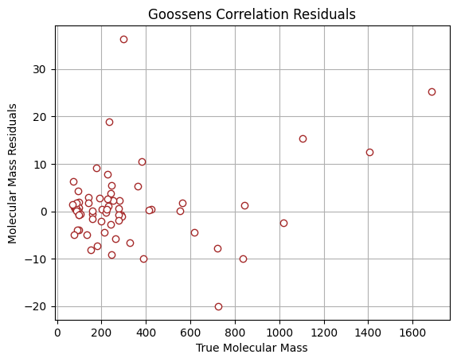

Figure 19: Goossens Correlation Residuals

This looks largely similar to the default-run residuals, until it is noticed that the zero line does not bisect the plot. The Shapiro-Wilk test p-value is zero to *six* significant figures.

#### Power Run

Our Second experiment is to drop the “division” binary operator $\left (\frac{a}{b} \right )$ and add the “power” binary operator $\left (a^b \right )$ as the latter is a popular component of the existing correlations.

There is noticeable drop in the quality of the match visually:

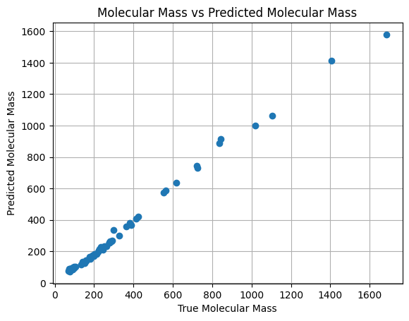

Figure 20: Power Operator Run

Although the equation has got simpler:

$$M_w=a_{00} \cdot a_{01}^{\gamma_o^{-a_{02}} + a_{03} \cdot T_b} + a_{04} \tag{37}$$

and the correlation coefficient has degraded slightly:

Table 11: Power Operator Run Correlation Coefficients

|  | Raw SG | Raw TBP | Raw MW | This Equation |
| --- | --- | --- | --- | --- |
| Raw SG | 1.000000 | 0.625218 | 0.334852 | 0.325151 |
| Raw TBP | 0.625218 | 1.000000 | 0.869591 | 0.868747 |
| Raw MW | 0.334852 | 0.869591 | 1.000000 | 0.997281 |
| This Equation | 0.325151 | 0.868747 | 0.997281 | 1.000000 |

One can argue that nested exponents $\left (a^{b^c} \right )$ aren’t very explainable. However the Stratiev correlation (Equation 35) does this with Euler’s number $\left ( a \cdot e^{b \cdot e^{c}} \right )$. In the hydrocarbon flow literature, nested logarithms $ln(ln(a))$ are more common.

#### Exponential Run

Our third experiment was to replace the binary power operator with unary logarithm and exponential operators. Our initial results were a major surprise as neither transcendental operator made it to the final equation:

$$M_w= - T_b \cdot \left(a_{00} \cdot T_b - a_{01}\right) \left(a_{02} \cdot 10^{-6} \left(a_{03} \cdot \gamma_o - 2 \cdot T_b \right) \left(T_b - a_{04}\right) - 1\right) + a_{05} \tag{38}$$

Accordingly, we re-set the random number generator and tried again:

$$M_w= a_{00}\cdot T_b + a_{01} \cdot e^{- \gamma_o^{2} + a_{02}\cdot \gamma_o + a_{03} \cdot T_b} \tag{39}$$

This is a dramatically different equation. This experience suggests that the *real* reason the deterministic algorithms are still under active development today is to avoid this kind of ambiguity.

Our correlation coefficients are *still* not as good as the default run:

Table 12: Exponential Run Correlation Coefficients

|  | Raw SG | Raw TBP | Raw MW | 1st Equation | 2nd Equation |
| --- | --- | --- | --- | --- | --- |
| Raw SG | 1.000000 | 0.625218 | 0.334852 | 0.348819 | 0.344733 |
| Raw TBP | 0.625218 | 1.000000 | 0.869591 | 0.869577 | 0.867574 |
| Raw MW | 0.334852 | 0.869591 | 1.000000 | 0.997705 | 0.998420 |
| First Equation | 0.348819 | 0.869577 | 0.997705 | 1.000000 | 0.999497 |
| Second Equation | 0.344733 | 0.867574 | 0.998420 | 0.999497 | 1.000000 |

*But* the risk of “division by zero” errors during extrapolation are negligible.

Also notable in this run is the absence of the logarithm function to linearize the relationship between these two variables:

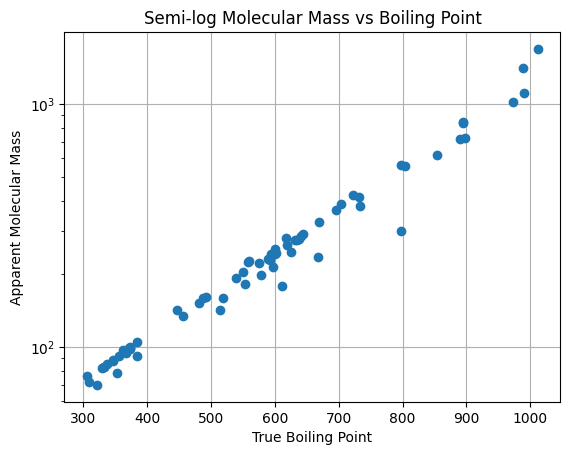

Figure 21: Raw Data Scale Change

This “obvious” human observation appears not to be an optimum transformation, or was eliminated by the evolutionary algorithm before it could reach its full potential.

#### Aeon Run

The fourth experiment is the same as the third experiment, except that we run it for ten times as long. Here, we are interested in whether different starting points will eventually converge to similar equations.

Here is the first equation after a thousand iterations:

$$M_w=(a_{00}\cdot T_b-a_{01})e^{a_{02}\cdot 10^{-9}T_b^2(a_{03}\cdot \gamma_0 +a_{04}\cdot T_b)}
\tag{40}$$

And the second equation[^3]:

$$M_w=-a_{00}\cdot \gamma_o+\frac{e^{-\gamma_o^2+{log(T_b)}^3}}{T_b^{a_{01}}} +a_{02}\cdot T_b
\tag{41}$$

The correlation coefficients, however, now rival the default run:

Table 13: Aeon Run Correlation Coefficients

|  | Raw Mw | First Equation | Second Equation |
| --- | --- | --- | --- |
| Raw Mw | 1.000000 | 0.998880 | 0.999324 |
| First Equation | 0.998880 | 1.000000 | 0.998851 |
| Second Equation | 0.999324 | 0.998851 | 1.000000 |

Both equations have evolved significantly by adding 900 iterations, but “similar, they are not” as [everyone’s favourite 900 year old](https://en.wikipedia.org/wiki/Yoda) would say.

The second equation is truly fascinating for two reasons. Neither the power operator $\left (a^b \right )$ nor the division operator $\left (\frac{a}{b} \right)$ were provided to the algorithm for this run, and yet we have found the middle expression $\left( \frac{e^{-\gamma_o^2+{log(T_b)}^3}}{T_b^{a_{01}}} \right)$.

#### Box-Cox Run

The reader may remember that our molecular mass (Figure 5) was *not* normally distributed. Accordingly, here we transform our dependent variable to see if this improves the distribution of our residuals. Our optimum exponent works out to be $-0.3624$ according to the python `stats` library, which is fairly close to zero.

Our transformed molecular mass distribution is hardly normal:

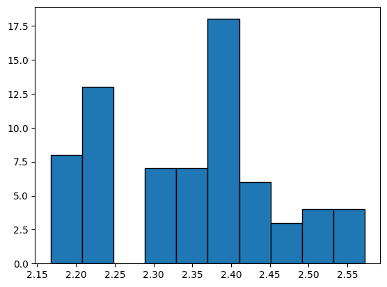

Figure 22: transformed molecular mass histogram

The other thing the reader may have noticed in Figure 22 is that the transformed variable range is much narrower. If we round-up to an exponent of zero, then our transform will now be logarithmic:

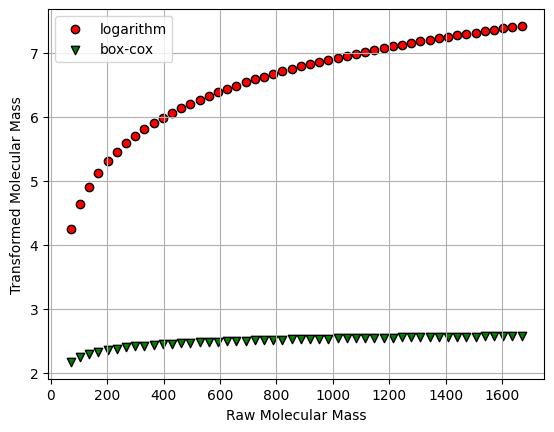

Figure 23: transformed molecular mass

This expands the range of the dependent variable but probably makes it less Gaussian. Let us go in the opposite direction and round-down to an inverse square root:

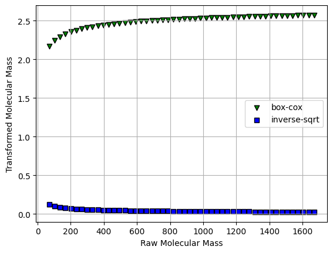

Figure 24: transformed molecular mass

This appears to compress the range of the transformed variable even more. Let us stay with $\lambda=-0.3624$ and press on. Using all four basic binary operators (like the default case) and adding exponentials and logarithms (like the exponential case), our fit looks quite good in Box-Cox space:

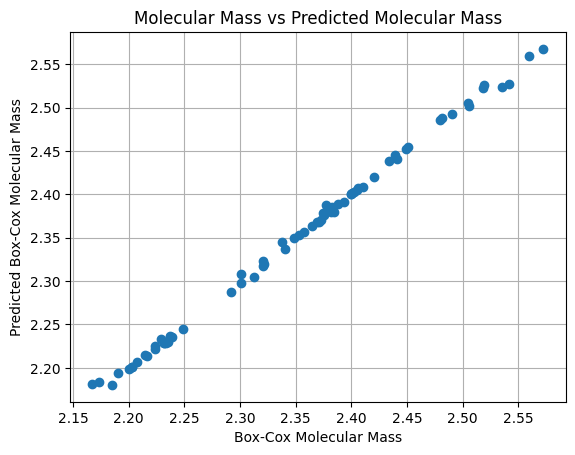

Figure 25: transformed prediced vs. actual, Box-Cox Run

The residuals in Box-Cox space are more spread-out:

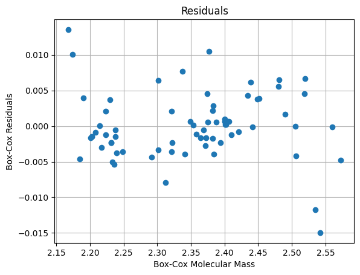

Figure 26: transformed Residuals, Box-Cox Run

And the Shapiro-Wilk test calculates the probability of the residuals being normal to 0.0507, which although higher, is barely over a level of significance of 0.05. When we untransform the predictions, and compare them to the measured molecular masses, the fit looks a little smoother:

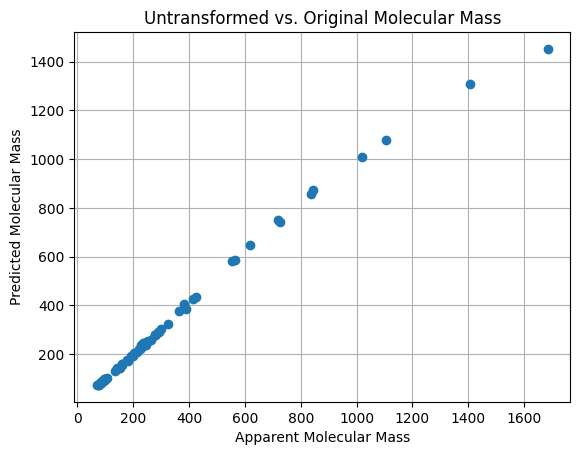

Figure 27: Untransformed prediced vs. actual, Box-Cox Run

This run produced the same equation structure at 100, 500 and 1000 iterations, which was *not* the case for the `PySR` runs in the Aeon experiment above:

$$M_w^t = \left (\gamma_o \left(a_{00} T_b -a_{01} \right) log{(\gamma_o)} + a_{02} \right) log{(T_b)} \tag{42}$$

We do need to remember to reverse the Box-Cox transform:

$$M_w = {\left(\lambda M_w^t +1 \right)}^{\frac{1}{\lambda}} \tag{43}$$

Table 14: Box-Cox Run Correlation Coefficients (Transform Reversed)

|  | Raw Mw | This Equation |
| --- | --- | --- |
| Raw Mw | 1.000000 | 0.995897 |
| This Equation | 0.995897 | 1.000000 |

A quick look at the residuals between the Reverse-Transformed predictions and the raw molecular masses tell the story:

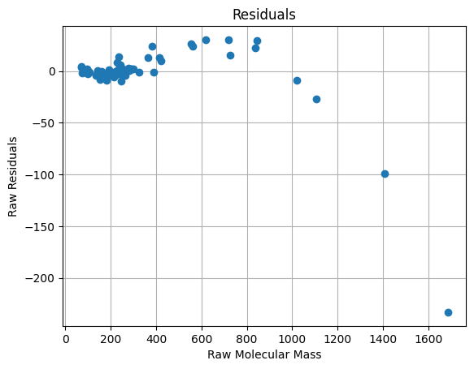

Figure 28: Residuals outside of Box-Cox Space, Box-Cox Run

Residuals are small for molecular masses below about 350, but explode above 1000. Statistically speaking, this may be good if we are more uncertain about the accuracy of the larger molecular masses, but the engineering point of view is different for exactly the same reason. Larger deviation from existing datapoints in regions where the datapoints are scarce is risky business.

#### First Sparse Run

It would seem remiss to not *at least* look at one of the deterministic models. The first library to work without requiring long-depreciated versions of Python is `SyMANTIC` (Muthyala et al. (2025)) so we set up the run to be equivalent the the *Default Run* above. Our “winning” equation is:

$$M_w=-a_{00} \cdot \gamma_o +\frac{a_{01}\cdot \gamma_o}{T_b}+a_{02}\cdot T_b -a_{03} \tag{44}$$

Compare this to Equation 41. Similar, but much simpler. The quality of the fit, however, is disappointing:

Table 15: First Sparse Run Correlation Coefficients

|  | Raw Mw | This Equation |
| --- | --- | --- |
| Raw Mw | 1.000000 | 0.970451 |
| This Equation | 0.970451 | 1.000000 |

A pleasant surprise is that we will have no “division by zero” problems with this equation as $T_b$ is in Kelvin.

A sparse regression model, “under the hood” is just a linear regression model. Accordingly, even though we are not thrilled with the fit, maybe the residuals are normal…

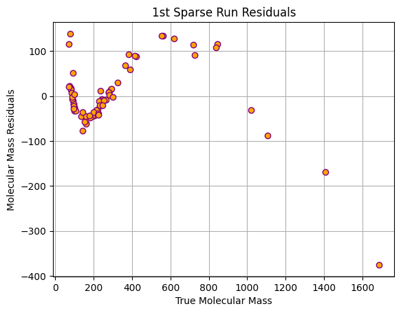

Figure 29: 1st Sparse Run Residuals

Never mind. Even if these residuals are normal (*they are not*) they are *definitely not* random. Moving right along…

#### Second Sparse Run

This leads to a second deterministic experiment, in which we add the logarithm and exponential functions, but leave the division operator in place. These is the same operator set used in the Box-Cox run above.

Our new equation is *not* complex either:

$$M_w=-a_{00}\cdot \gamma_o\cdot T_b +a_{01}\cdot T^2_b +a_{02}\cdot e^{\gamma_o} +a_{03} \tag{45}$$

And our fit improves slightly:

Table 16: Second Sparse Run Correlation Coefficients

|  | Raw Mw |  |
| --- | --- | --- |
| Raw Mw | 1.000000 |  |
| 1st Run Equation | 0.970451 |  |
| 2nd Run Equation | 0.985800 |  |

But our plot of measured molecular mass versus predicted molecular mass is not impressive at all:

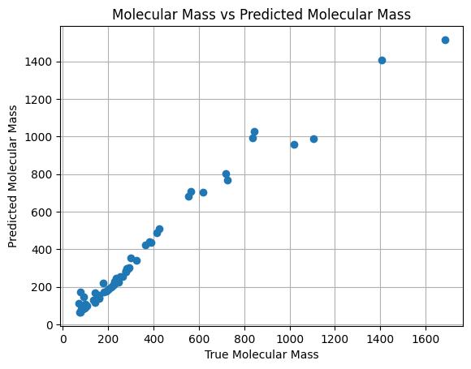

Figure 30: Second Sparse Run

#### Validation Runs

As promised, we used the Hosseinifar dataset of 10 records (12.5%) to validate some of these equations:

Table 17: Validation Run Correlation Coefficients

| Run | Correlation Coefficient |
| --- | --- |
| Raw Mw | 1.000000 |
| Default | 0.999957 |
| Goossens Correlation | 0.999939 |
| Power | 0.996964 |
| Exponential #2 | 0.998954 |
| Aeon #1 | 0.999973 |
| Aeon #2 | 0.999921 |
| Box-Cox | 0.999696 |
| Sparse #1 | 0.992303 |
| Sparse #2 | 0.996331 |

A better approach with the evolutionary model is probably to start increasing `parsimony` or decreasing `maxsize` or `maxdepth` until the correlation coefficients start to deteriorate.

A different approach is warranted with the deterministic models. It is possible that these are *underfit*, meaning that we can expand the number of unique terms the algorithm initially considers, or the number of terms we want to keep.

#### General Observations

The “UOP Characterization Factor” Equation 21 which (at least) two researchers decided was an important correlating variable for molecular mass, was not discovered by our symbolic regression model.

In fairness, however, we dropped the division operator early in our experimentation, and never asked the model to consider a “cube root” unary operator.

Replication is very challenging with these symbolic regression libraries that use evolutionary algorithms. Re-running the same dataset on the same machine with the same libraries produces different equations. In many `Scikit-Learn` algorithms, answer variation can be minimized by seeding the random number generator the same way each time, but in `PySR` we also have to turn off the optimizations that allow Julia to run the calculations massively in parallel, which contributes to the criticism that these algorithms are slow.

The deterministic symbolic regression libraries don’t need random number seeds, and the answers stay the same between runs. The equations are definitely more *explainable*, but appear to be less accurate. Does this accuracy matter? Is it real? The answer to these questions depend on how good we think our measurements are!

In the engineering world, an old trick to speed-up calculations is to use look-up tables instead of functions. The idea is that even though we may know exactly what the governing equations are, producing look up tables from these functions ahead of time and then applying Gaussian interpolation in real time may be faster. This is a *very* similar concept to the idea of pre-training a transformer network to do symbolic regression.

This paper has shown that high fidelity models can be constructed from “cheap” components (i.e. arithmetic operators). Maybe *explainability* is overrated, and functions carefully built using symbolic regression may be competitive with old-man Gauss!

If this turns out to be true, then symbolic regression will make the full circle and return to it roots.

### Conclusions

In summary, we have explored Symbolic Regression using evolutionary and deterministic algorithms on our molecular mass dataset. We have not spent much time on different kinds of engines (e.g. neural networks, mathematical programming) or tested the extrapolation chops of this technology.

Our main conclusions are:

1. Symbolic Regression can generate reasonable predictions when trained on datasets too small for neural networks.
2. Evolutionary Symbolic Regression will typically generate novel equations from the human point of view, but these equations can be as accurate than the ones created by humans.
3. The “explainability” of the generated equations are probably overrated, unless enough guardrails are put up to constrain the space searched by the evolutionary Symbolic Regression algorithm.
4. The ability of Evolutionary Symbolic Regression to easily find alternative equations of about the same accuracy means that humans can repeat the workflow until an equation that is more “explainable” than the others is generated.
5. The structure of an equation generated with symbolic regression *will* withstand some noise.
6. Piping the “winning” equation through a symbolic mathematics package to simplify and consolidate it is a good idea. The effect on the deterministic equations is very slight.
7. This consolidation often introduces relationships between variables and constants that were not specified before the algorithm was started. This can nudge the human to reconsider relationships previously rejected.
8. All Symbolic Regression libraries using evolutionary algorithms are *not* created equal. Library comparison is beyond the scope of this report, but we can comment that `PySR`was one of the better ones.
9. Running both evolutionary and deterministic models on the same problem is *also* a good idea.

## References

Anthes, Philipp, Dominik Sobania, and Franz Rothlauf. 2025. “Transformer Semantic Genetic Programming for Symbolic Regression.” *arXiv Preprint arXiv:2501.18479*.

Austel, Vernon, Sanjeeb Dash, Oktay Gunluk, Lior Horesh, Leo Liberti, Giacomo Nannicini, and Baruch Schieber. 2017. “Globally Optimal Symbolic Regression.” *arXiv Preprint arXiv:1710.10720*.

Bongard, Josh, and Hod Lipson. 2007. “Automated Reverse Engineering of Nonlinear Dynamical Systems.” *Proceedings of the National Academy of Sciences* 104 (24): 9943–48.

Box, George EP, and David R Cox. 1964. “An Analysis of Transformations.” *Journal of the Royal Statistical Society Series B: Statistical Methodology* 26 (2): 211–43.

Breiman, Leo, and Jerome H Friedman. 1985. “Estimating Optimal Transformations for Multiple Regression and Correlation.” *Journal of the American Statistical Association* 80 (391): 580–98.

Brunton, Steven L, Joshua L Proctor, and J Nathan Kutz. 2016. “Discovering Governing Equations from Data by Sparse Identification of Nonlinear Dynamical Systems.” *Proceedings of the National Academy of Sciences* 113 (15): 3932–37.

Cranmer, Miles. 2023. “Interpretable Machine Learning for Science with PySR and SymbolicRegression. Jl.” *arXiv Preprint arXiv:2305.01582*.

Dong, Junlan, and Jinghui Zhong. 2025. “Recent Advances in Symbolic Regression.” *ACM Computing Surveys* 57 (11): 1–37.

Goossens, Adriaan G. 1996. “Prediction of Molecular Weight of Petroleum Fractions.” *Industrial & Engineering Chemistry Research* 35 (3): 985–88.

Hosseinifar, Pouya, and Hamidreza Shahverdi. 2021. “A Predictive Method for Constructing the Distillation Curve of Petroleum Fluids Using Their Physical Bulk Properties.” *Journal of Petroleum Science and Engineering* 200: 108403.

Kamienny, Pierre-Alexandre, Stéphane d’Ascoli, Guillaume Lample, and François Charton. 2022. “End-to-End Symbolic Regression with Transformers.” *Advances in Neural Information Processing Systems* 35: 10269–81.

Keren, Liron Simon, Alex Liberzon, and Teddy Lazebnik. 2023. “A Computational Framework for Physics-Informed Symbolic Regression with Straightforward Integration of Domain Knowledge.” *Scientific Reports* 13 (1): 1249.

Koza, John R. 1994. “Genetic Programming as a Means for Programming Computers by Natural Selection.” *Statistics and Computing* 4 (2): 87–112.

Liu, Ziming, Yixuan Wang, Sachin Vaidya, Fabian Ruehle, James Halverson, Marin Soljačić, Thomas Y Hou, and Max Tegmark. 2024. “Kan: Kolmogorov-Arnold Networks.” *arXiv Preprint arXiv:2404.19756*.

Martius, Georg, and Christoph H Lampert. 2016. “Extrapolation and Learning Equations.” *arXiv Preprint arXiv:1610.02995*.

Muthyala, Madhav R, Farshud Sorourifar, You Peng, and Joel A Paulson. 2025. “SyMANTIC: An Efficient Symbolic Regression Method for Interpretable and Parsimonious Model Discovery in Science and Beyond.” *Industrial & Engineering Chemistry Research* 64 (6): 3354–69.

Noorian, Farzad, Anthony M de Silva, and Philip HW Leong. 2016. “gramEvol: Grammatical Evolution in r.” *Journal of Statistical Software* 71: 1–26.

Sahoo, Subham, Christoph Lampert, and Georg Martius. 2018. “Learning Equations for Extrapolation and Control.” In *International Conference on Machine Learning*, 4442–50. Pmlr.

Shannon, Claude E. 2001. “A Mathematical Theory of Communication.” *ACM SIGMOBILE Mobile Computing and Communications Review* 5 (1): 3–55.

Shapiro, Samuel Sanford, and Martin B Wilk. 1965. “An Analysis of Variance Test for Normality (Complete Samples).” *Biometrika* 52 (3-4): 591–611.

Stratiev, Dicho, Sotir Sotirov, Evdokia Sotirova, Svetoslav Nenov, Rosen Dinkov, Ivelina Shishkova, Iliyan Venkov Kolev, et al. 2023. “Prediction of Molecular Weight of Petroleum Fluids by Empirical Correlations and Artificial Neuron Networks.” *Processes* 11 (2): 426.

Udrescu, Silviu-Marian, and Max Tegmark. 2020. “AI Feynman: A Physics-Inspired Method for Symbolic Regression.” *Science Advances* 6 (16): eaay2631.

Virgolin, Marco, and Peter AN Bosman. 2022. “Coefficient Mutation in the Gene-Pool Optimal Mixing Evolutionary Algorithm for Symbolic Regression.” In *Proceedings of the Genetic and Evolutionary Computation Conference Companion*, 2289–97.

## Footnotes

[^1]: A post-fix variant was used on scientific calculators in the 1970’s as it was more efficient. The learning curve, however, was brutal for mere mortals, so that owning one of these ‘RPN’ [artifacts](https://en.wikipedia.org/wiki/HP-35) became a status symbol in the engineering community well into the 1990’s.
[^2]: No algorithms were harmed during the making of this paper.
[^3]: A quick note for humans on this second equation: ${log(T_b)}^3 = {(ln(T_b))}^3 \neq ln(T^3_b)$ This was made clear by inspecting the Polish Notation version of the equation. Just sayin’.